# Red Wine Data Exploration and Summary

### **Introduction**

This report explores a dataset containing 11 variables on the chemical properties of 1,599 red wines. At least 3 wine experts rated the quality of each wine, providing a rating between 0 (very bad) and 10 (very excellent). The 13th variable listed in the dataset dimensions below is an index column.

### **Univariate Plots Section**

**Dataset dimensions**

```
## [1] 1599   13
```

**Dataset overview**

```
## 'data.frame':    1599 obs. of  13 variables:
##  $ X                   : int  1 2 3 4 5 6 7 8 9 10 ...
##  $ fixed.acidity       : num  7.4 7.8 7.8 11.2 7.4 7.4 7.9 7.3 7.8 7.5 ...
##  $ volatile.acidity    : num  0.7 0.88 0.76 0.28 0.7 0.66 0.6 0.65 0.58 0.5 ...
##  $ citric.acid         : num  0 0 0.04 0.56 0 0 0.06 0 0.02 0.36 ...
##  $ residual.sugar      : num  1.9 2.6 2.3 1.9 1.9 1.8 1.6 1.2 2 6.1 ...
##  $ chlorides           : num  0.076 0.098 0.092 0.075 0.076 0.075 0.069 0.065 0.073 0.071 ...
##  $ free.sulfur.dioxide : num  11 25 15 17 11 13 15 15 9 17 ...
##  $ total.sulfur.dioxide: num  34 67 54 60 34 40 59 21 18 102 ...
##  $ density             : num  0.998 0.997 0.997 0.998 0.998 ...
##  $ pH                  : num  3.51 3.2 3.26 3.16 3.51 3.51 3.3 3.39 3.36 3.35 ...
##  $ sulphates           : num  0.56 0.68 0.65 0.58 0.56 0.56 0.46 0.47 0.57 0.8 ...
##  $ alcohol             : num  9.4 9.8 9.8 9.8 9.4 9.4 9.4 10 9.5 10.5 ...
##  $ quality             : int  5 5 5 6 5 5 5 7 7 5 ...
```

The dataset contains 13 variables with 1599 observations. The first variable, ‘X’, is an index. Variables 2-12 measure the chemical properties of the red wines. Variable 13 is the quality rating of the wine as assessed by experts.

**Summary Statistics of Variables**

```
##        X          fixed.acidity   volatile.acidity  citric.acid
##  Min.   :   1.0   Min.   : 4.60   Min.   :0.1200   Min.   :0.000
##  1st Qu.: 400.5   1st Qu.: 7.10   1st Qu.:0.3900   1st Qu.:0.090
##  Median : 800.0   Median : 7.90   Median :0.5200   Median :0.260
##  Mean   : 800.0   Mean   : 8.32   Mean   :0.5278   Mean   :0.271
##  3rd Qu.:1199.5   3rd Qu.: 9.20   3rd Qu.:0.6400   3rd Qu.:0.420
##  Max.   :1599.0   Max.   :15.90   Max.   :1.5800   Max.   :1.000
##  residual.sugar     chlorides       free.sulfur.dioxide
##  Min.   : 0.900   Min.   :0.01200   Min.   : 1.00
##  1st Qu.: 1.900   1st Qu.:0.07000   1st Qu.: 7.00
##  Median : 2.200   Median :0.07900   Median :14.00
##  Mean   : 2.539   Mean   :0.08747   Mean   :15.87
##  3rd Qu.: 2.600   3rd Qu.:0.09000   3rd Qu.:21.00
##  Max.   :15.500   Max.   :0.61100   Max.   :72.00
##  total.sulfur.dioxide    density             pH          sulphates
##  Min.   :  6.00       Min.   :0.9901   Min.   :2.740   Min.   :0.3300
##  1st Qu.: 22.00       1st Qu.:0.9956   1st Qu.:3.210   1st Qu.:0.5500
##  Median : 38.00       Median :0.9968   Median :3.310   Median :0.6200
##  Mean   : 46.47       Mean   :0.9967   Mean   :3.311   Mean   :0.6581
##  3rd Qu.: 62.00       3rd Qu.:0.9978   3rd Qu.:3.400   3rd Qu.:0.7300
##  Max.   :289.00       Max.   :1.0037   Max.   :4.010   Max.   :2.0000
##     alcohol         quality
##  Min.   : 8.40   Min.   :3.000
##  1st Qu.: 9.50   1st Qu.:5.000
##  Median :10.20   Median :6.000
##  Mean   :10.42   Mean   :5.636
##  3rd Qu.:11.10   3rd Qu.:6.000
##  Max.   :14.90   Max.   :8.000
```

##### **Exploration Goal**

I want to understand how the chemical properties of red wine relate to quality rating. Which properties correlate most with the highest and lowest rated wines? Are there any interesting relationships between the various chemical properties of the wines?

##### **Histogram of Quality**

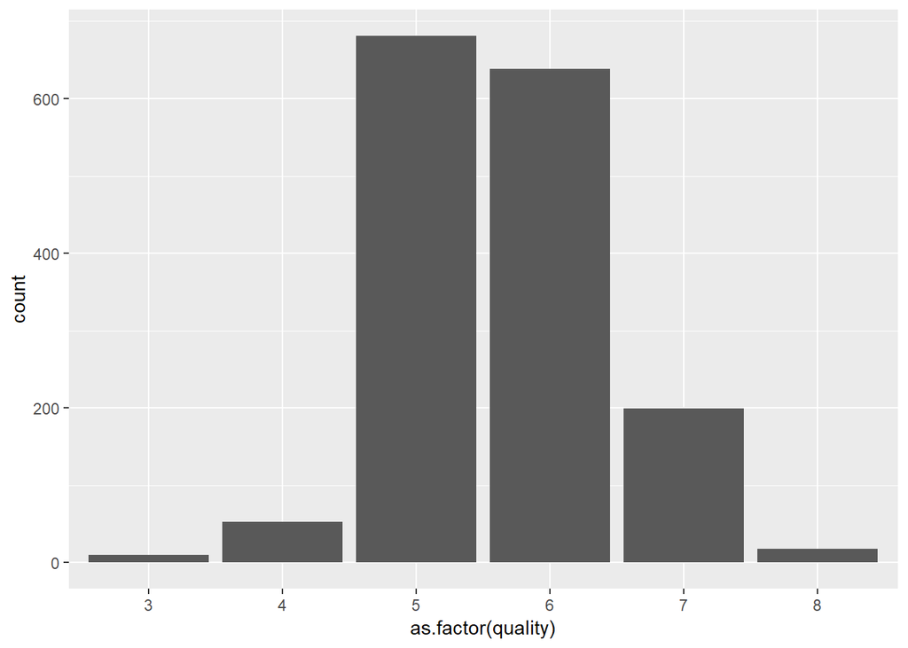

All of the wines in the dataset have a rating between 3 and 8, with most rated 5 or 6.

##### **Histograms of all chemical properties of the wines**

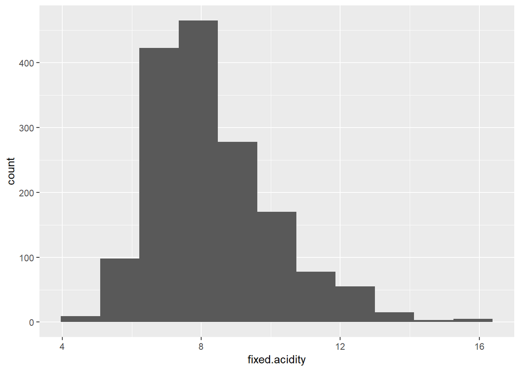

Fixed acidity is right skewed with a mean that appears to be around 8 or 9.

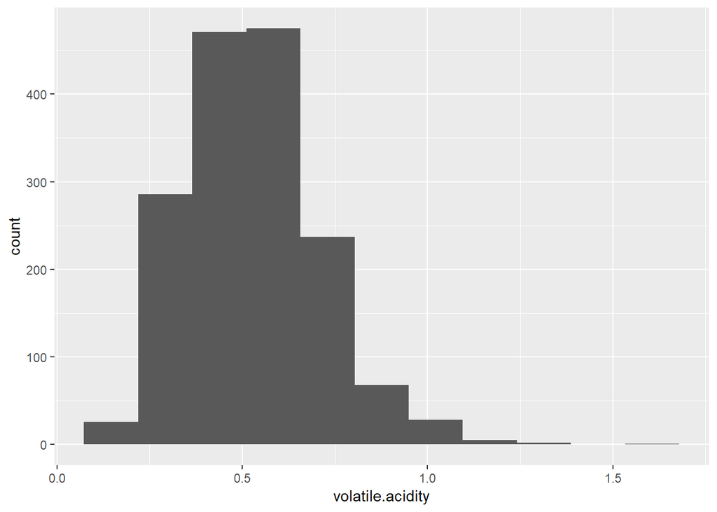

Volatile acidity is strongly right skewed. A few wines have a volatile acidity level roughly three times the mean.

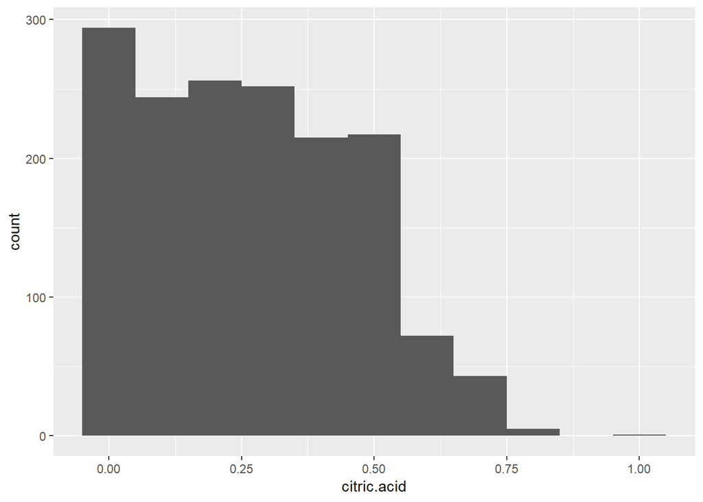

Citric acid is tightly grouped in the bottom 50% of the range. The distribution has a skinny tail at the top of the range.

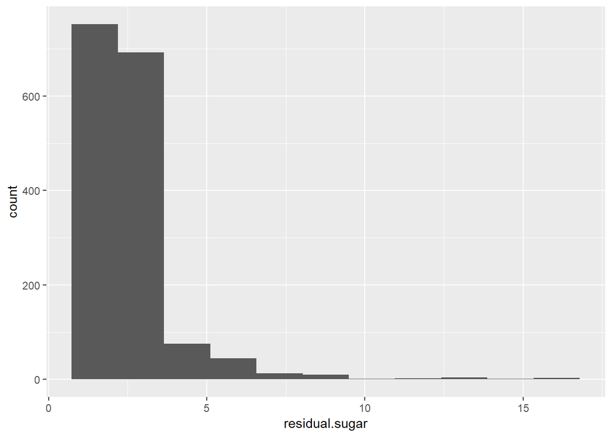

Residual sugar has a very skinny long tail. A few wines in the dataset have a significantly higher residual sugar level than nearly all of the rest of the wines.

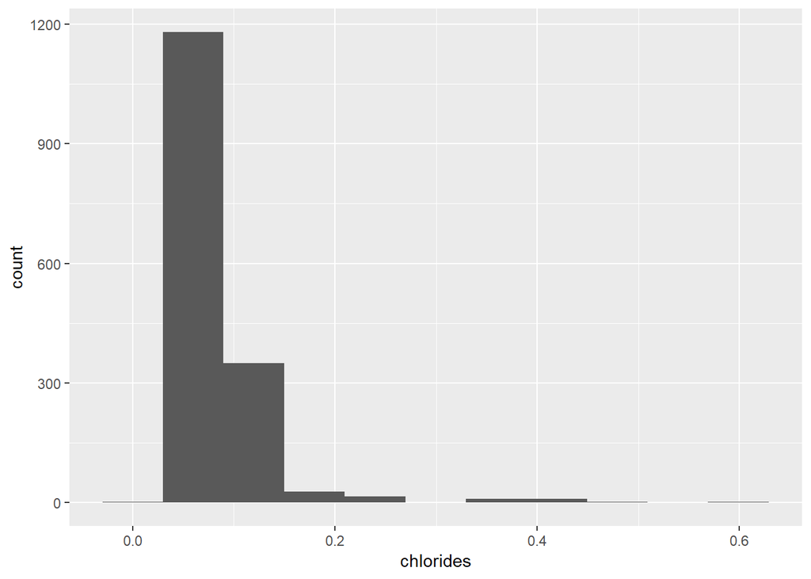

The chloride levels for the majority of the wines is tightly distributed with a long skinny tail on the right.

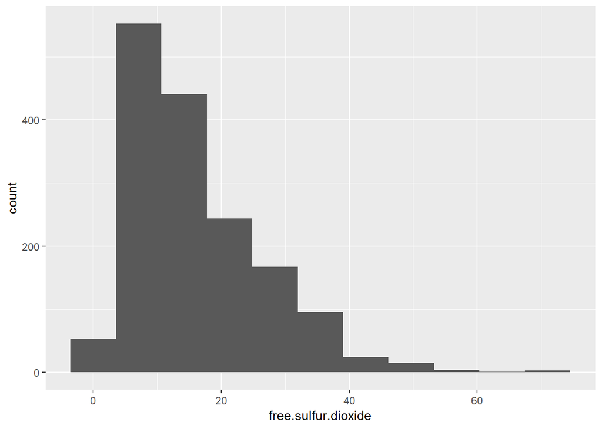

The free sulfur dioxide distribution is right skewed with a fat long tail on the right.

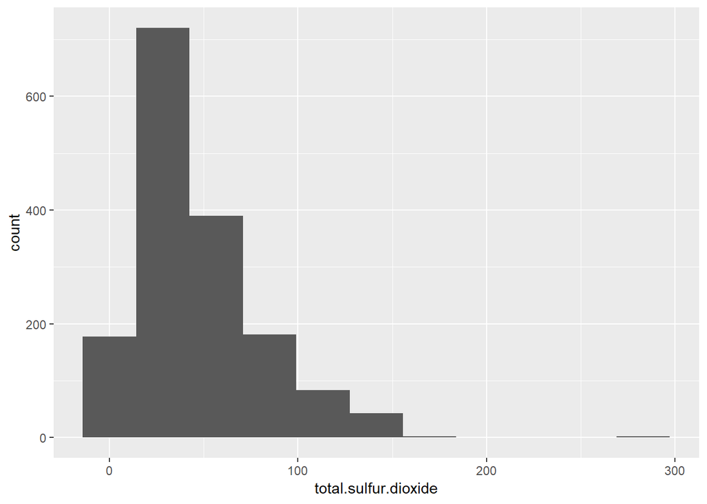

Very few wines have a total sulfur dioxide level that is significantly higher than the rest of the wines. This is another right skewed distribution.

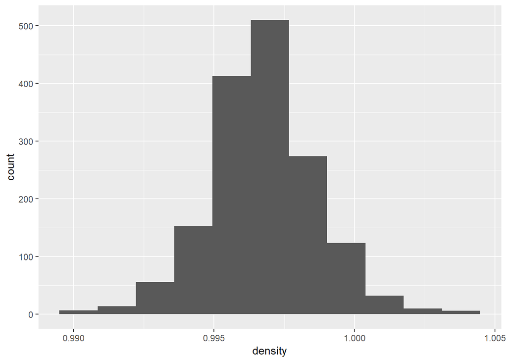

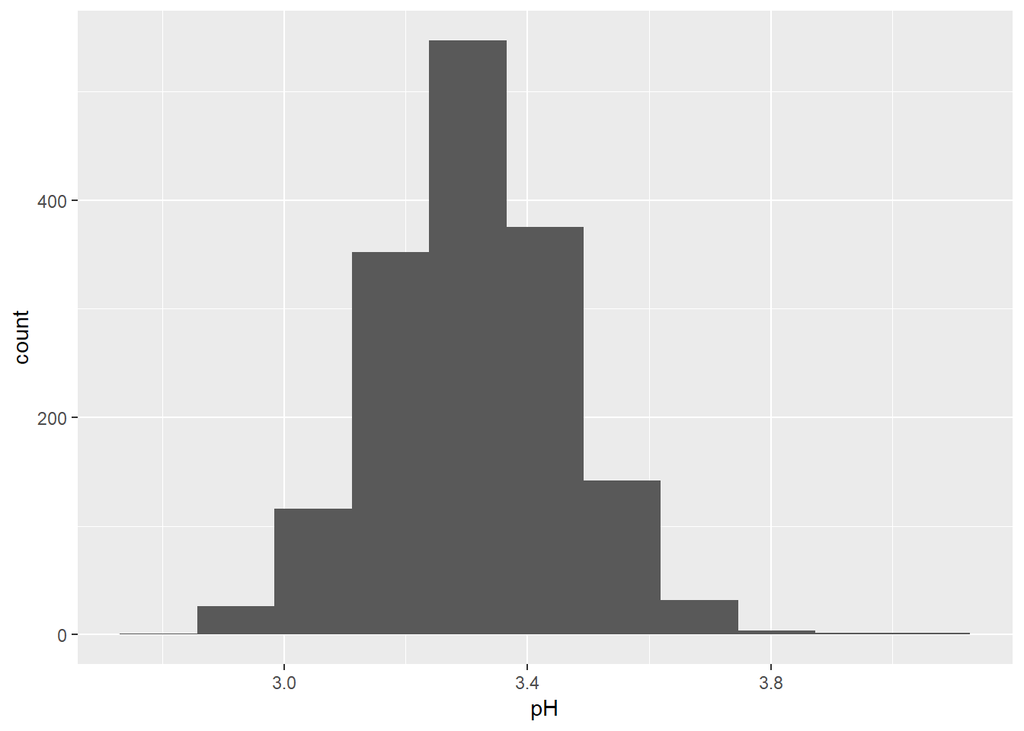

pH also is roughly normally distributed.

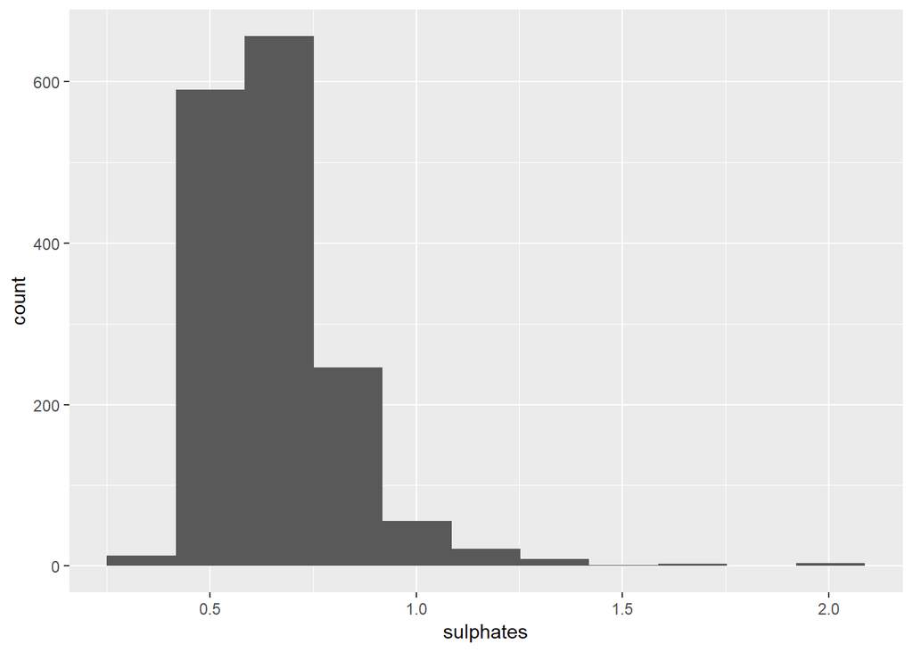

Sulphate levels are very right skewed with a long skinny tail. A few wines have sulphate levels 3-4x higher than the mean.

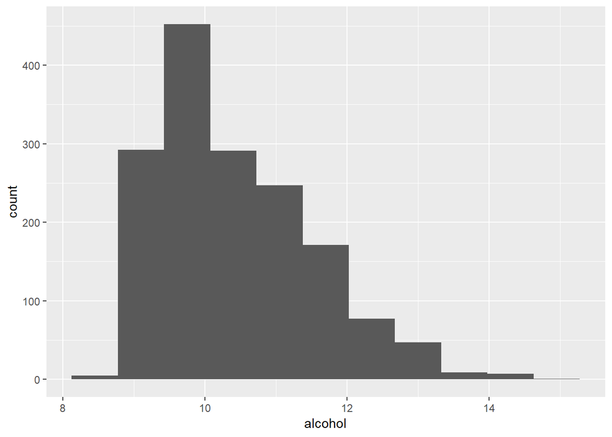

Alcohol is right skewed but there is a fat right tail, so there is a number of wines throughout the distribution of alcohol levels.

I want to compare the chemical properties for wines with the worst and best quality ratings and see if this helps me identify which properties to examine more closely.

**Summary statistics for each variable for wines with a quality rating of 3**

```
##        X          fixed.acidity    volatile.acidity  citric.acid
##  Min.   : 460.0   Min.   : 6.700   Min.   :0.4400   Min.   :0.0000
##  1st Qu.: 726.5   1st Qu.: 7.150   1st Qu.:0.6475   1st Qu.:0.0050
##  Median :1100.0   Median : 7.500   Median :0.8450   Median :0.0350
##  Mean   :1053.2   Mean   : 8.360   Mean   :0.8845   Mean   :0.1710
##  3rd Qu.:1446.2   3rd Qu.: 9.875   3rd Qu.:1.0100   3rd Qu.:0.3275
##  Max.   :1506.0   Max.   :11.600   Max.   :1.5800   Max.   :0.6600
##  residual.sugar    chlorides      free.sulfur.dioxide total.sulfur.dioxide
##  Min.   :1.200   Min.   :0.0610   Min.   : 3.0        Min.   : 9.0
##  1st Qu.:1.875   1st Qu.:0.0790   1st Qu.: 5.0        1st Qu.:12.5
##  Median :2.100   Median :0.0905   Median : 6.0        Median :15.0
##  Mean   :2.635   Mean   :0.1225   Mean   :11.0        Mean   :24.9
##  3rd Qu.:3.100   3rd Qu.:0.1430   3rd Qu.:14.5        3rd Qu.:42.5
##  Max.   :5.700   Max.   :0.2670   Max.   :34.0        Max.   :49.0
##     density             pH          sulphates         alcohol
##  Min.   :0.9947   Min.   :3.160   Min.   :0.4000   Min.   : 8.400
##  1st Qu.:0.9961   1st Qu.:3.312   1st Qu.:0.5125   1st Qu.: 9.725
##  Median :0.9976   Median :3.390   Median :0.5450   Median : 9.925
##  Mean   :0.9975   Mean   :3.398   Mean   :0.5700   Mean   : 9.955
##  3rd Qu.:0.9988   3rd Qu.:3.495   3rd Qu.:0.6150   3rd Qu.:10.575
##  Max.   :1.0008   Max.   :3.630   Max.   :0.8600   Max.   :11.000
##     quality
##  Min.   :3
##  1st Qu.:3
##  Median :3
##  Mean   :3
##  3rd Qu.:3
##  Max.   :3
```

**Summary statistics for each variable for wines with a quality rating of 8**

```
##        X          fixed.acidity    volatile.acidity  citric.acid
##  Min.   : 268.0   Min.   : 5.000   Min.   :0.2600   Min.   :0.0300
##  1st Qu.: 462.5   1st Qu.: 7.250   1st Qu.:0.3350   1st Qu.:0.3025
##  Median : 709.0   Median : 8.250   Median :0.3700   Median :0.4200
##  Mean   : 826.7   Mean   : 8.567   Mean   :0.4233   Mean   :0.3911
##  3rd Qu.:1182.5   3rd Qu.:10.225   3rd Qu.:0.4725   3rd Qu.:0.5300
##  Max.   :1550.0   Max.   :12.600   Max.   :0.8500   Max.   :0.7200
##  residual.sugar    chlorides       free.sulfur.dioxide
##  Min.   :1.400   Min.   :0.04400   Min.   : 3.00
##  1st Qu.:1.800   1st Qu.:0.06200   1st Qu.: 6.00
##  Median :2.100   Median :0.07050   Median : 7.50
##  Mean   :2.578   Mean   :0.06844   Mean   :13.28
##  3rd Qu.:2.600   3rd Qu.:0.07550   3rd Qu.:16.50
##  Max.   :6.400   Max.   :0.08600   Max.   :42.00
##  total.sulfur.dioxide    density             pH          sulphates
##  Min.   :12.00        Min.   :0.9908   Min.   :2.880   Min.   :0.6300
##  1st Qu.:16.00        1st Qu.:0.9942   1st Qu.:3.163   1st Qu.:0.6900
##  Median :21.50        Median :0.9949   Median :3.230   Median :0.7400
##  Mean   :33.44        Mean   :0.9952   Mean   :3.267   Mean   :0.7678
##  3rd Qu.:43.00        3rd Qu.:0.9972   3rd Qu.:3.350   3rd Qu.:0.8200
##  Max.   :88.00        Max.   :0.9988   Max.   :3.720   Max.   :1.1000
##     alcohol         quality
##  Min.   : 9.80   Min.   :8
##  1st Qu.:11.32   1st Qu.:8
##  Median :12.15   Median :8
##  Mean   :12.09   Mean   :8
##  3rd Qu.:12.88   3rd Qu.:8
##  Max.   :14.00   Max.   :8
```

# Univariate Analysis

### What is the structure of your dataset?

There are 1599 red wines in the data set, with 12 features (quality, fixed acidity, volatile acidity, citric acid, residual sugar, chlorides, free sulfur dioxide, total sulfur dioxide, and density). The quality rating is an ordered factor, and while it is a numerical variable, it is really a categorical variable.

- Most wines have a quality rating of 5 or 6. None of the wines were rated as low as 0, 1, or 2. None of them were rated as high as 9 or 10.
- The mean value for each chemical property is as follows
  - fixed acidity - 8.32
  - volatile acidity - 0.5278
  - citric acid - 0.271
  - residual sugar - 2.539
  - chlorides - 0.08747
  - free sulfur dioxide - 15.87
  - total sulfur dioxide - 46.47
  - density - 0.9967
  - pH - 3.311
  - sulphates - 0.6581
  - alcohol - 10.42
  - quality - 5.636
- Density and pH are both normally distributed, and the distributions of the other chemical properties have varying degrees of right-skewness.

### What is/are the main feature(s) of interest in your dataset?

The main feature of the dataset is quality. My interest in examining the data is to understand the chemical properties of the wines that correlate with a wine receiving a specific expert quality rating.

### Did you create any new variables from existing variables in the dataset?

I did not create any new variables.

### Of the features you investigated, were there any unusual distributions?

Did you perform any operations on the data to tidy, adjust, or change the form  
of the data? If so, why did you do this? Since the dataset was already very tidy, I didn’t need to change anything.

# Bivariate Plots Section

Looking at scatter plots for each chemical property I want examine more closely vs. quality lets me quickly see how each property is distributed for each quality rating.

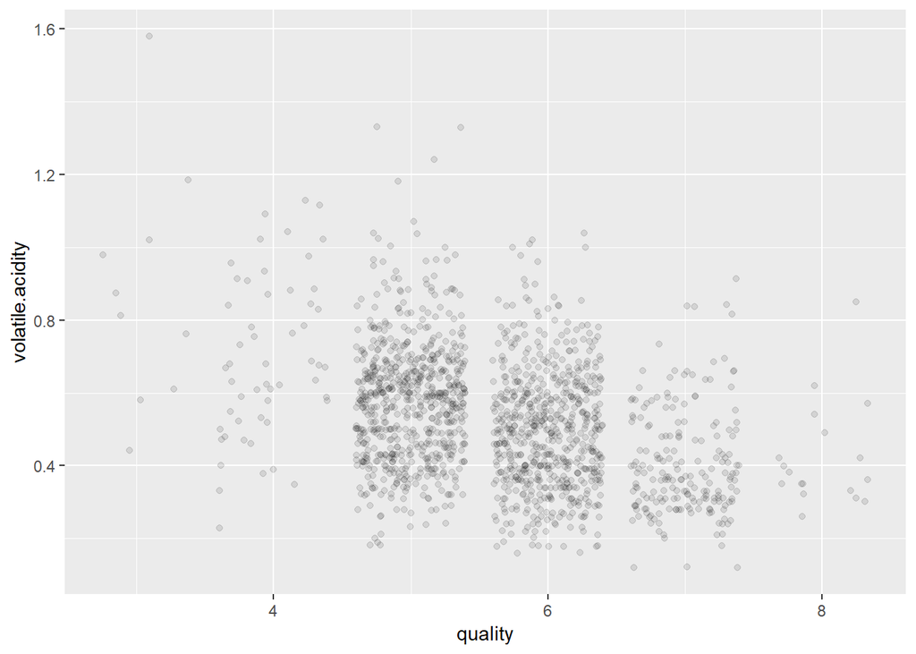

The distribution of volatile acidity is the lowest and tightest for the highest rated wines.

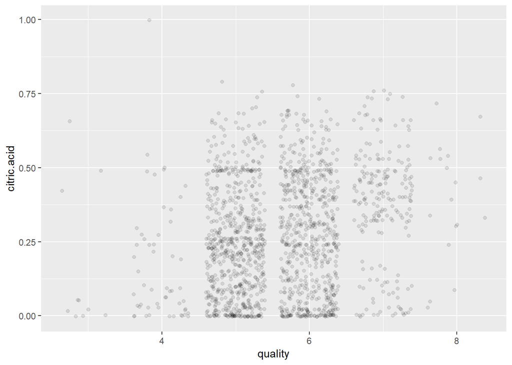

Citric acid doesn’t tell a strong story.

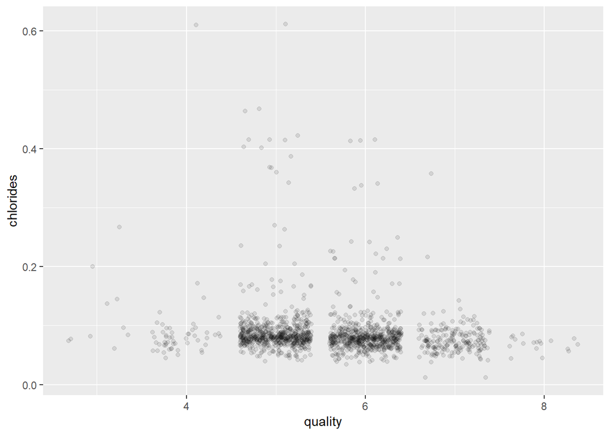

The distribution of chlorides for the highest rated wines is the tighest and lowest of all.

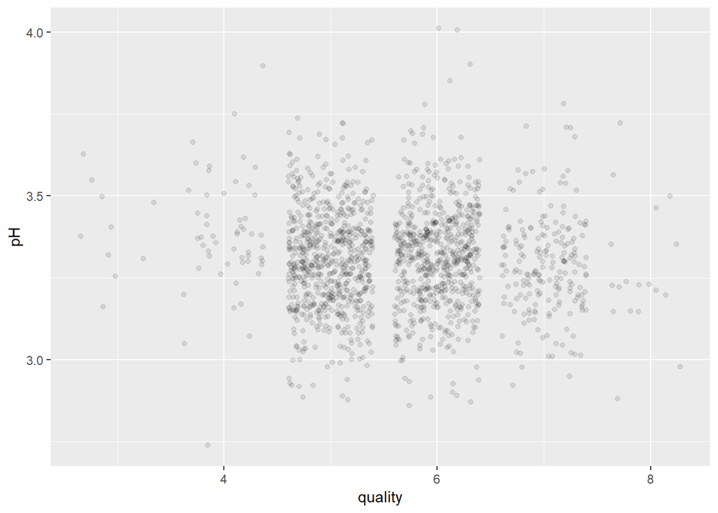

All quality ratings have a wide range of pH values.

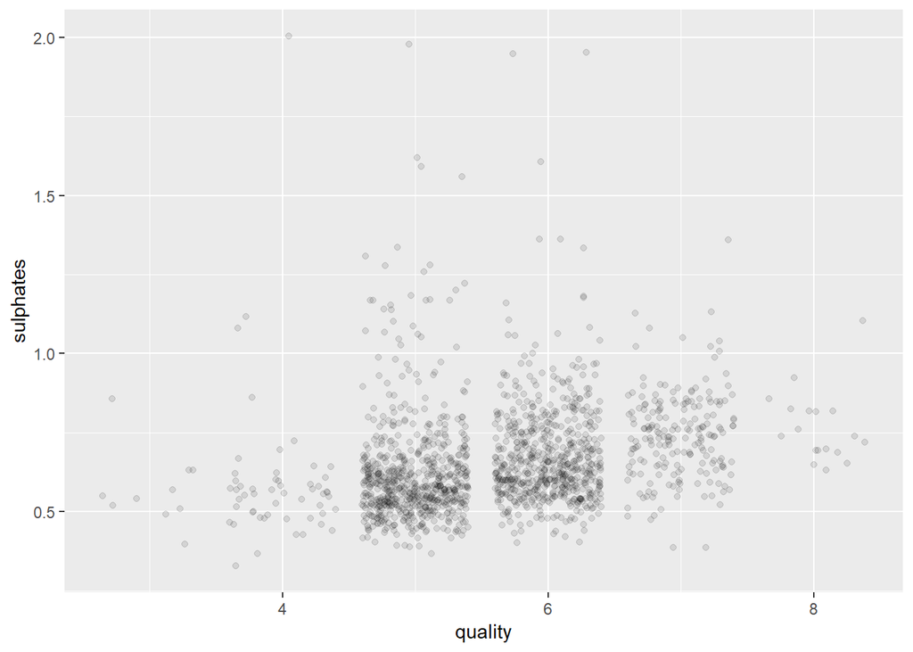

Wines rated 3 and 4 have some of the lowest means sulphates. The distribution of sulphates in the highest rated wines are tightly grouped.

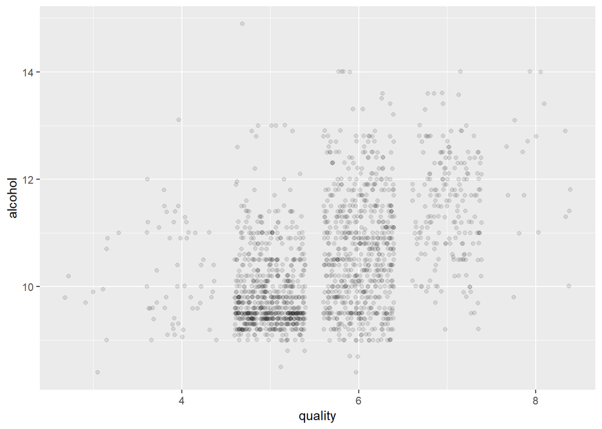

While each rating has relatively wide distribution of alcohol levels, in general, as alcohol goes up, quality rating goes up.

Let’s look at a correlation plot of the chemical properties and quality. The plot will also give a brief overview of any other interesting relationships between any of the variables.

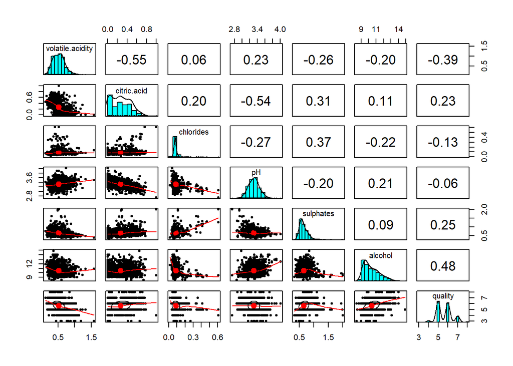

Because of the lack of strong relationships in the above correlation plot, I’m curious to look at all the variables

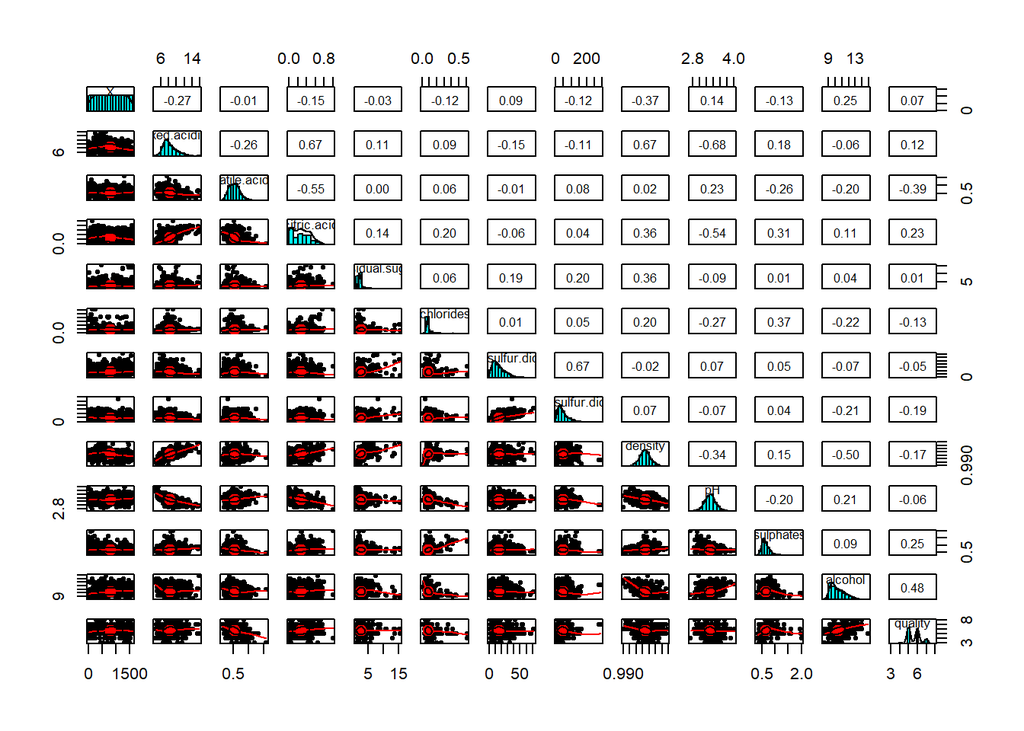

I was wondering if quality and residual sugar had any relationship. Since the reviewers are experts, not casual wine drinkers, sweetness doesn’t play a factor here. The correlation coefficient is 0.01!

Quality, volatile acidity, and alcohol share relatively high correlations, so I was curious to see them graphed together.

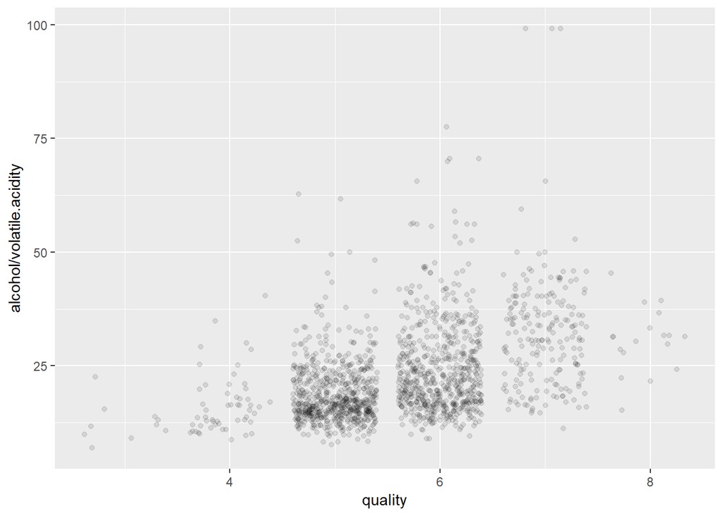

The lowest rated wines all have very low ratios of alcohol to volatile acidity.

I’m curious to see if the proprtion of sulfur dioxide that is ‘free’ is any different across quality ratings.

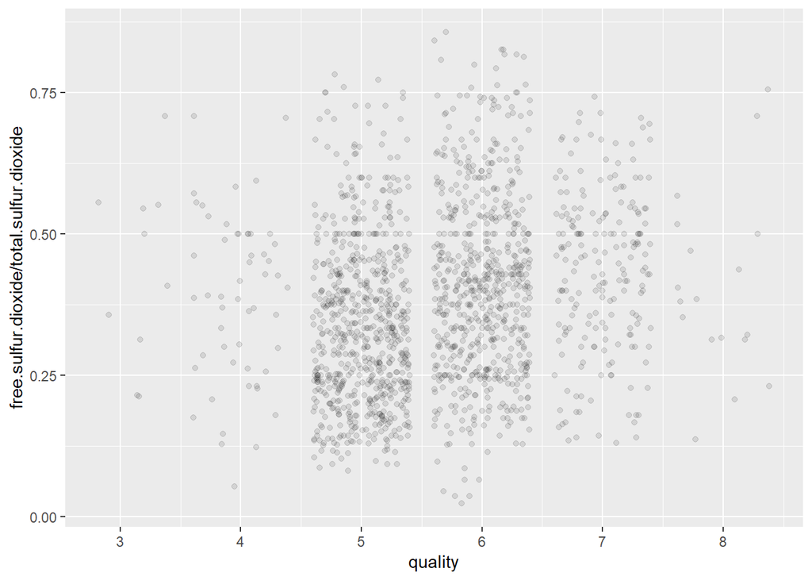

Volatile acidity negatively correlates with quality and fixed acidity correlates positively, albeit weakly. I’m curious if the ratio of volatile to fixed acidity relates interestingly with quality

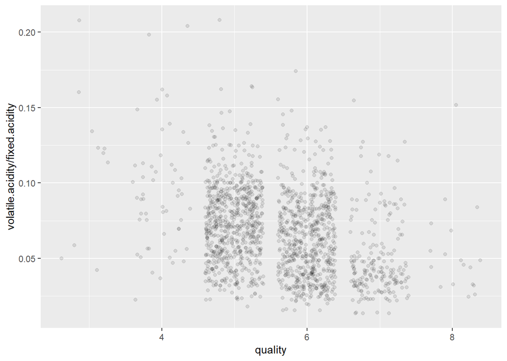

With one exception, the highest rated wines have a low ratio of volatile to fixed acidity.

# Bivariate Analysis

More than any other quality rating, the worst rated wines all shared a low ratio of alcohol to volatile acidity. The lowest ratio of alcohol to volatile acidity of all belonged to wine with a quality rating of 3.

- Fixed acidity and density: r = 0.67
- Fixed acidity and citric acid: r = 0.67 (yes, both are 0.67) The more of a specific acid, the higher the overall acid.
- Alcohol and density: r = -0.50 This makes sense because water’s density is 997 kg/m^3 and ethanol’s density is 789 kg/m^3, so the higher the proportion of alcohol in the wine, the lower the density will be.

Examining the ratio of volatile acidity to fixed acidity in the wines showed that all but one of the highest rated wines shared a low ratio. All the other quality ratings had wide distributions of this ratio.

# Multivariate Plots Section

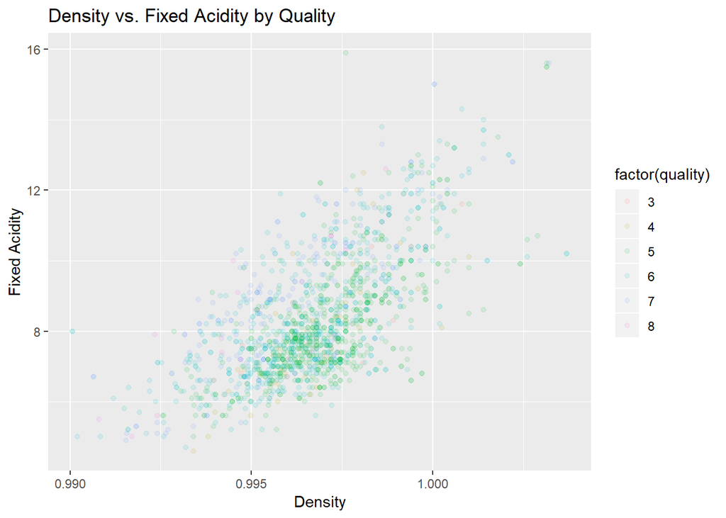

A moderately strong linear relationship is visible here, but we can see that there are no strong groupings of quality in the data. The dominance of 5 and 6 quality rated wines is also apparent.

[figure not shown]

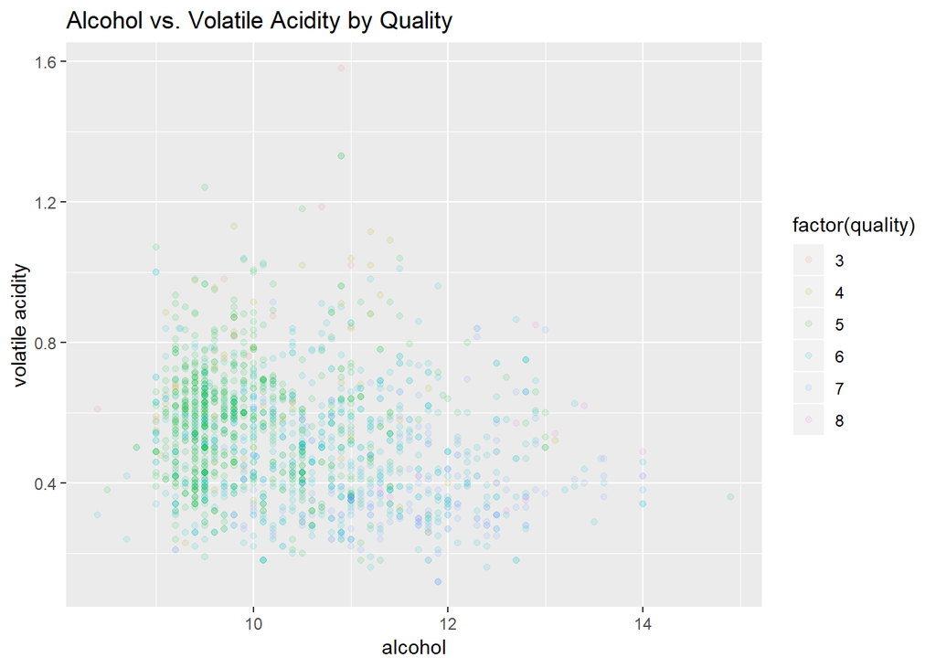

Here we can see a concentration 5-rated wines in the lower-left quadrant, but other than that there’s not much of a relationship apparent.

# Multivariate Analysis

### Were there any interesting or surprising interactions between features?

The linearity of the relationship between density and fixed acidity was surprising. There may be some underlying chemical principals that explains this, but this was not obvious at the outset. I was surprised that were wasn’t an interaction of chemical properties that related more strongly to quality.

# Final Plots and Summary

### Plot One

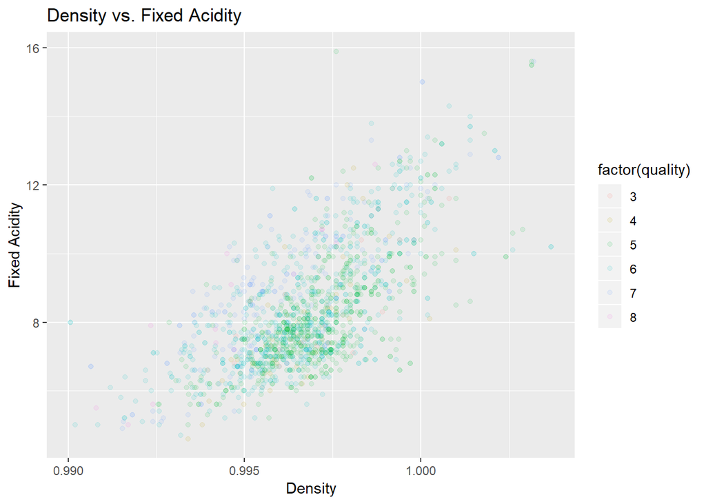

### Description One

There is a moderately strong relationship (r=0.67) between fixed acidity and density. However, by observing the color in the scatterplot to identify trends in the relationship between quality and fixed acidity/density, we can see that there isn’t a strong trend.

### Plot Two

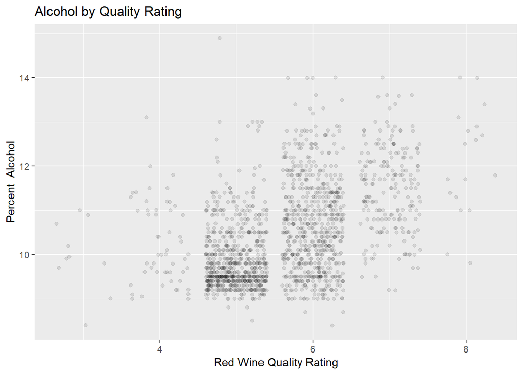

### Description Two

This plot clearly shows that Quality Rating increases with Alcohol. The lowest rated wines had a tight distribution of low Alcohol percentage.

### Plot Three

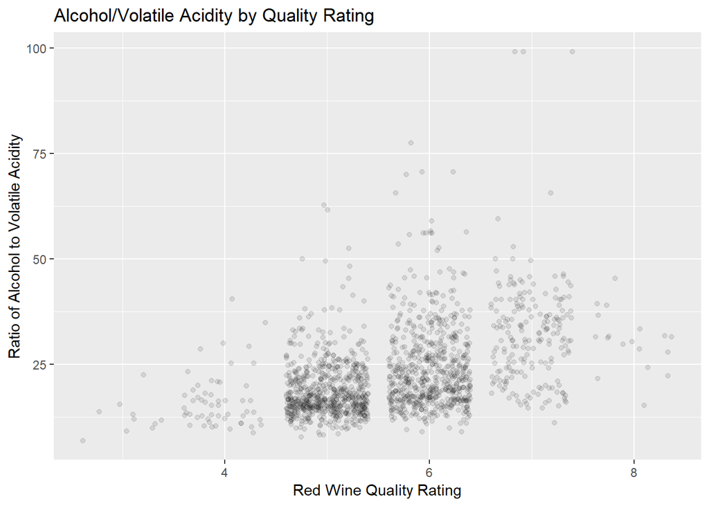

# Reflection

In examining the data, I set out to focus my bivariate analyis on the chemical properties that had a linear trend from the mean of the lowest rated wines to the dataset mean to the mean of the highest rated wines. This lead me quickly to some moderately explanatory graphs, but again, nothing that was terribly strong and clear.

It was a bit frustrating looking for relationship in the data in general. There was no ‘smoking gun’ or big, obvious story in the data. It would be interesting to examine a dataset with ratings from a single expert and try to determine what role the preferences of the expert rater plays in the relationships between chemical properties and quality rating. It would also be interesting to compare ratings of untrained wine drinkes to those of experts for the same wines. I have read articles in the past that highlighted the inabilities of wine raters to consistently rate the same wine. This dynamic may contribute to the fact that the chemical property with the strongest correlation to quality was alcohol, which doesn’t seem like a property that would strongly effect the quality of the wine within a reasonable range.

To investigate the dataset further, I would build a linear model to understand which variables or interactions of variables best explain the quality ratings of the wines. A dataset with wines from more regions outside Portugal might provide less skewed distributions for the chemical properties, which could enhance the predictive power of a linear model.